# Reproducible Research: Peer Assessment 1

Eric BAUDON

Sunday, September 13, 2015

In this is an R Markdown document we are going to perform simple data exploratory with a collection of data coming from an experimental measurment performed in Ocotber and November 2012. In this lattest, we measured the number of steps performed every 5min interval during 61 days. Results are collected in csv file called “activity”.

# Loading and preprocessing the data

First we need to load and clean data for working. I loaded the “activity.csv” file from my desktop and i studied the dataframe collection with following code:

```r
data<-read.csv("C:/Users/Eric BAUDON/Desktop/activity.csv")
str(data)
```

```
## 'data.frame':    17568 obs. of  3 variables:
##  $ steps   : int  NA NA NA NA NA NA NA NA NA NA ...
##  $ date    : Factor w/ 61 levels "2012-10-01","2012-10-02",..: 1 1 1 1 1 1 1 1 1 1 ...
##  $ interval: int  0 5 10 15 20 25 30 35 40 45 ...
```

As we can see, it is composed of 3 varaibles: - step: An integer counting the numbers of steps performed - date: A factor representing the date the observation was performed - interval: An integer representing the subdvision of day in 5 min steps.

For latter usage, we need to convert the date format as Date and not as Factor. We did so with the following code:

```r
data[,2]<-as.Date(data[,2],format="%Y-%m-%d")
```

# What is mean total number of steps taken per day?

Firts we calculated the Total number of steps per days with the following code:

```r
library(dplyr)
data.tot<-group_by(data,date)
somme<-summarize(data.tot,sm=sum(steps))
```

Then we printed this repartition

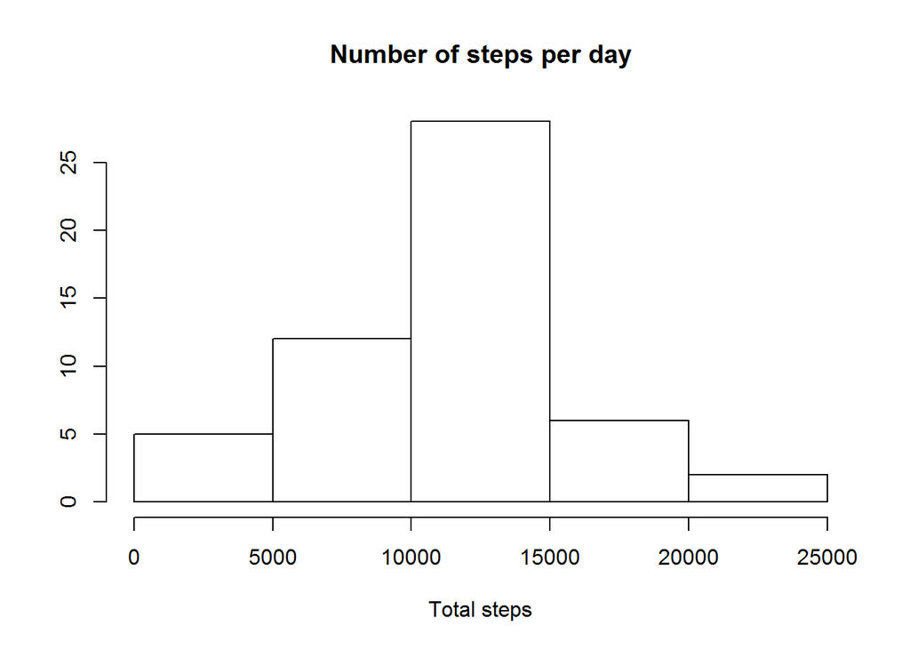

```r
hist(somme$sm, main="Number of steps per day",xlab="Total steps",ylab="")
```

```r
mean.tot<-mean(somme$sm,na.rm = TRUE)
median.tot<-median(somme$sm, na.rm = TRUE)
```

# What is the average daily activity pattern?

In this section we would like to analyse and compare the daily activity of the subject based upon day time. For this we can used our intervals subdivisions and we are going to find mean over each intervals. For this, we re-arrnage our datas with the following R code:

```r
data.daily<-group_by(data,interval)
steps<-summarize(data.daily,mn=mean(steps,na.rm = TRUE))
```

We can then print our daily activies:

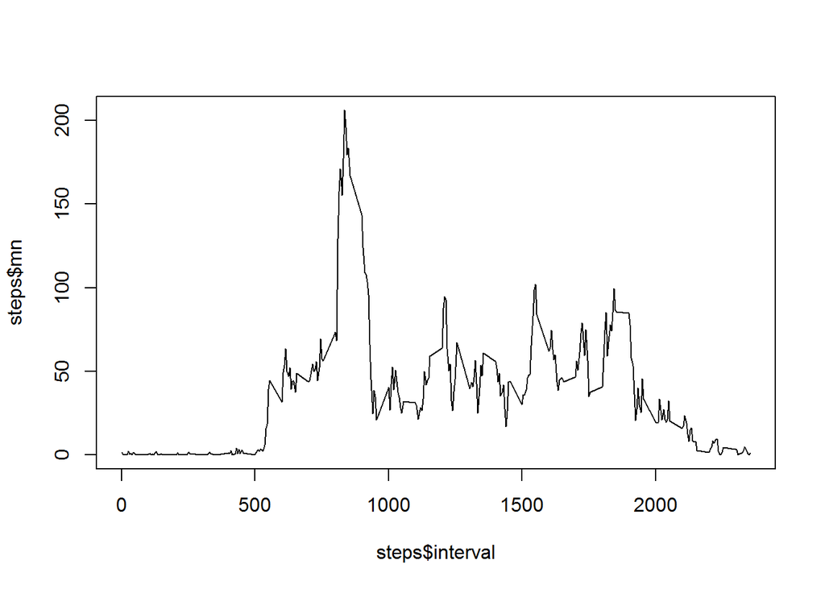

```r
plot(steps$interval,steps$mn,type = "l")
```

We can also calculate at what time, in average, we perform the maximum of steps during the day:

```r
test<-max(steps$mn)
filter(steps, mn==test)$interval
```

```
## [1] 835
```

# Imputing missing values

As we observed previously, there are some missing values stored as NA values. We can calculate the number of missing with the following code:

```r
sum(is.na(data$steps))
```

```
## [1] 2304
```

In order to see if these missing values have any impact, we are going to fill them with daily interval averages calculated previously. So, for each NA value, we are going to replace it with by the mean value calculated by intervals with the following code:

```r
data.clean<-data
for (i in 1:length(data$steps))
{
    if(is.na(data.clean[i,1]))
    {
        inter = data.clean[i,3]
        stepnew = filter(steps,interval == inter)$mn
        data.clean[i,1]=stepnew
    }
}
```

```r
sum(is.na(data$steps))
```

```
## [1] 2304
```

Finally, lets check if the missing NA creat any bias in our study by reperforming the Total Number steps by days calculations:

```r
data.clean.tot<-group_by(data.clean,date)
somme.clean<-summarize(data.clean.tot,sm=sum(steps))

mean.clean<-mean(somme.clean$sm)
median.clean<-median(somme.clean$sm)
```

And we can plot the new histogram:

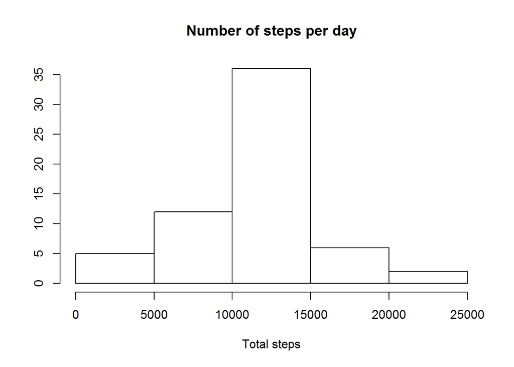

```r
hist(somme.clean$sm, main="Number of steps per day",xlab="Total steps",ylab="")
```

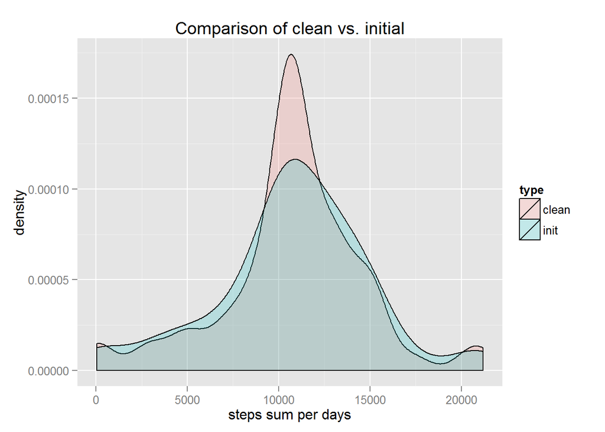

```r
data1<-mutate(somme,type="init")
data2<-mutate(somme.clean,type="clean")
data.print<-rbind.data.frame(data1,data2)
library(ggplot2)
ggplot(data.print, aes(sm, fill = type)) + geom_density(alpha = 0.2) + labs(x="steps sum per days")+labs(title="Comparison of clean vs. initial")
```

As we can see, our manipulation only re-centered our collection to give it a more gaussien shap. So the missing NA were not critical and didn’t bias our initial studies.

# Are there differences in activity patterns between weekdays and weekends?

```r
data.week<-data.clean
data.week<-mutate(data.week,daytype="weekday")
for (i in 1:length(data.week$steps))
{
    wday=weekdays(data.week[i,2])
    if(wday=="samedi"){data.week[i,4]<-"weekend"}
    if(wday=="dimanche"){data.week[i,4]<-"weekend"}
    }
```

Then we performed the daily activity study for intervals activity but we subdivided our calculation on both separated weekdays and weekends days. The final result is a plot showing the average activity pattern for our subject during weekday and weekends.

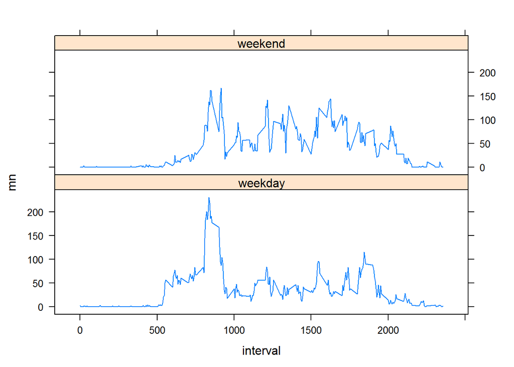

```r
data.week<-group_by(data.week,daytype,interval)
final<-summarize(data.week,mn=mean(steps))
library("lattice")
xyplot(mn~interval|daytype, data = final,type="l",layout = c(1, 2))
```